# Análise Estatística dos Dados Históricos do UFC

CE302 — Elementos de Programação para Estatística

Autores

Afiliação

Felipe

Estudante de graduação em Estatística, UFPR

Lucas

Estudante de graduação em Estatística, UFPR

Miguel Antunes de Lima

Estudante de graduação em Estatística, UFPR

Rafael Dias

Estudante de graduação em Estatística, UFPR

Data de Publicação

28/11/2026

# Resumo

Este estudo descreve o histórico de confrontos do Ultimate Fighting Championship (UFC) e investiga como os resultados se associam às características registradas dos atletas. A análise descritiva de 7177 lutas combina séries anuais dos métodos de encerramento com comparações pareadas de altura, envergadura, histórico de vitórias e média de quedas aplicadas entre vencedores e derrotados. Os perfis dos atletas, os rankings, as disputas de cinturão e a localização dos eventos contextualizam os confrontos. As decisões foram o método de encerramento mais frequente. As comparações por categoria mostraram variação na proporção de vencedores com medidas maiores que as dos derrotados. A cobertura das bases, os empates nas medidas e a repetição de atletas são relevantes para interpretar essas diferenças.

**Palavras-chave:** artes marciais mistas; análise descritiva; desempenho esportivo; categorias de peso.

# 1 Introdução

No Ultimate Fighting Championship (UFC), uma luta pode terminar antes do último round ou ser decidida pelos juízes. O histórico de confrontos permite comparar a frequência desses desfechos e investigar como as características dos atletas se associam ao resultado das lutas.

O objetivo é descrever a evolução do número de lutas e seus métodos de encerramento e comparar vencedores e derrotados em altura, envergadura, histórico de vitórias e média de quedas aplicadas. Para contextualizar os confrontos, o relatório examina o perfil dos atletas por categoria de peso, sua permanência nos rankings, as disputas de cinturão e a distribuição geográfica dos eventos.

# 2 Materiais e Métodos

## 2.1 Conjunto de dados

A coletânea *UFC Athletes and Fight Data*, publicada pelo TidyTuesday (R for Data Science Online Learning Community, 2026), reúne dados históricos de lutas, eventos, perfis de atletas, rankings e estatísticas de desempenho.

As análises de confrontos da Seção 3 utilizam o arquivo tratado `ufc_lutas_completo.rds`, derivado da versão de `ultimate_ufc_dataset.csv` publicada pelo TidyTuesday. Cada linha representa uma luta e reúne a data, a categoria de peso, o método de encerramento, o vencedor e as medidas dos atletas nos cantos vermelho e azul. Os perfis de atletas e as posições nos rankings vêm de `atletas_limpo.rds` e `rankings_limpo.rds`. A distribuição geográfica utiliza as contagens de eventos em `locais_mais_eventos.rds` e `paises_mais_eventos.rds`, derivadas do histórico `ufc_fights.csv`. O histórico de eventos e a base de confrontos têm coberturas diferentes.

## 2.2 Pré-processamento

O script `scripts/02_limpeza_ufc.R` padroniza datas e textos, converte pesos de libras para quilogramas e remove colunas de apostas e rankings divisionais esparsos.

## 2.3 Técnicas estatísticas e computacionais

As contagens anuais usam as lutas com data registrada. Para os métodos de encerramento, as decisões por unanimidade, divisão e maioria foram agrupadas. A proporção de cada método usa como denominador as lutas com método informado.

A comparação entre vencedores e derrotados considera lutas com vencedor identificado como vermelho ou azul. Para cada variável, calcula-se a diferença entre os valores do vencedor e do derrotado. Altura e envergadura são medidas em centímetros. Os indicadores de desempenho registram as vitórias anteriores no UFC e a média de quedas aplicadas por 15 minutos, conforme o dicionário de dados (R for Data Science Online Learning Community, 2026). A comparação usa pares com valores finitos. Medidas de altura ou envergadura iguais a zero são tratadas como ausentes, e os empates na variável permanecem no denominador. As proporções são calculadas para o conjunto das lutas e por categoria de peso, com o número de pares válidos indicado para cada medida. As lutas em peso combinado mantêm a classificação *Catch Weight* da base.

Nos perfis, valores iguais a zero em altura, envergadura e idade são tratados como ausentes. O resumo por categoria apresenta a média e o número de registros disponíveis para cada medida. Nos rankings divisionais, a permanência é medida pelo número de datas distintas em que cada atleta aparece, e a melhor posição corresponde ao menor valor registrado, com zero representando o campeão. Nas sínteses por gênero, a média da permanência considera cada combinação de atleta e divisão, enquanto os totais de atletas e campeões contam cada atleta uma vez em cada grupo. O retrato mais recente considera a última data disponível na base divisional.

Para as disputas de cinturão, aplica-se a correção de classificação documentada em `R/aba_09_cinturao.R` na versão integrada à `main`. O recorte usa as lutas marcadas como disputa de título com cinco rounds programados, mantém os registros de 11/07/2020 que o módulo identifica como exceção e retira as lutas da lista de exclusão do módulo. A taxa de vitória é calculada entre as disputas com vencedor registrado. Na análise geográfica, cada evento é contado uma vez pela combinação de nome, data e local, e as variações de endereço para a mesma cidade e país são somadas.

Os cálculos, as tabelas, os gráficos e os valores inseridos no texto são gerados em R (R Core Team, 2026) com o pacote `knitr` (Xie, 2026) durante a renderização do Quarto (Allaire et al., 2026a).

### 2.3.1 Reprodução do relatório

A renderização utiliza o Quarto, o R e os pacotes `knitr` e `rmarkdown` (Allaire et al., 2026b). O ambiente de referência usou Quarto 1.10.18, R 4.6.2, `knitr` 1.52 e `rmarkdown` 2.32. Os dados tratados estão em `dados_limpos/`. A renderização acessa pela internet o estilo CSL indicado no cabeçalho do documento.

Para instalar os pacotes no R, execute `install.packages(c("knitr", "rmarkdown"))`. Na raiz do repositório, gere o HTML com `quarto render relatorio/relatorio_ufc.qmd --to html`.

Para regenerar os arquivos tratados, o script `scripts/02_limpeza_ufc.R` lê os CSVs do TidyTuesday e carrega os pacotes `tidytuesdayR`, `lubridate`, `dplyr`, `readr`, `purrr` e `stringr`. O script de download `scripts/01_download.R` usa `here` para localizar a pasta `data/raw/`.

Os resultados geográficos do relatório são reproduzidos a partir de `locais_mais_eventos.rds` e `paises_mais_eventos.rds`. Na branch `main`, o mapa interativo da aba Locais & Eventos combina as contagens por cidade com `dados_auxiliares/coordenadas_cidades.csv` e usa o pacote `leaflet` para exibir os pontos.

# 3 Resultados e Discussão

## 3.1 Evolução do número de lutas

**Ver código**

Figura 1 – Número de lutas registradas por ano.

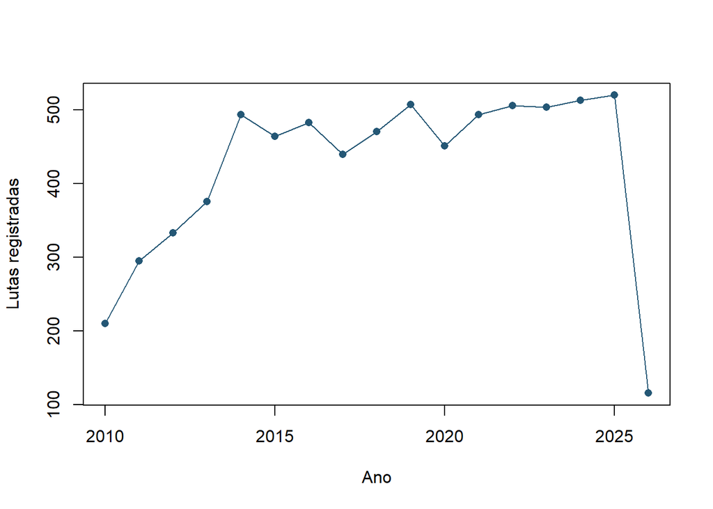

```r
anos <- table(format(lutas$date, "%Y"))
plot(as.integer(names(anos)), as.integer(anos), type = "o",
     pch = 16, col = "#245775", xlab = "Ano", ylab = "Lutas registradas")
```

Fonte: elaboração própria com dados do TidyTuesday (R for Data Science Online Learning Community, 2026).

A base contém 7177 lutas com datas entre 21/03/2010 e 28/03/2026. A Figura 1 mostra que 2025 teve a maior contagem do recorte, com 520 lutas. Os anos nas extremidades da série podem ter cobertura parcial.

## 3.2 Métodos de encerramento

**Ver código**

```r
metodo <- trimws(lutas$finish)
metodo[metodo %in% c("U-DEC", "S-DEC", "M-DEC")] <- "Decis\u00e3o"
metodo[metodo %in% "SUB"] <- "Finaliza\u00e7\u00e3o"
metodo[metodo %in% c("CNC", "DQ", "Overturned")] <- "Outros"
metodo[metodo %in% ""] <- NA_character_
frequencias <- sort(table(metodo), decreasing = TRUE)
resumo_metodos <- data.frame(
  Metodo = names(frequencias),
  Lutas = as.integer(frequencias),
  Percentual = round(100 * as.integer(frequencias) / sum(frequencias), 1)
)
knitr::kable(resumo_metodos, digits = 1,
             col.names = c("M\u00e9todo", "Lutas", "Percentual"),
             format.args = list(decimal.mark = ","))
```

Tabela 1 – Distribuição dos métodos de encerramento informados.

| Método | Lutas | Percentual |
| --- | --- | --- |
| Decisão | 3432 | 49,5 |
| KO/TKO | 2223 | 32,0 |
| Finalização | 1260 | 18,2 |
| Outros | 24 | 0,3 |

Fonte: elaboração própria com dados do TidyTuesday (R for Data Science Online Learning Community, 2026).

A Tabela 1 indica que o método mais frequente foi **Decisão**, com 3432 lutas. Houve 238 registros sem método informado.

### 3.2.1 Métodos de encerramento por ano e gênero

**Ver código**

Figura 2 – Distribuição percentual dos métodos de encerramento por ano e gênero.

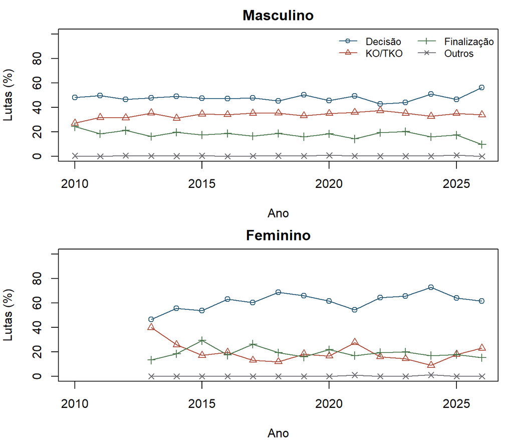

```r
genero <- factor(lutas$gender, levels = c("MALE", "FEMALE"),
                 labels = c("Masculino", "Feminino"))
contagens <- table(
  ano = format(lutas$date, "%Y"),
  metodo = factor(metodo, levels = names(frequencias)),
  genero = genero
)
percentuais <- 100 * prop.table(contagens, margin = c(1, 3))
percentuais[!is.finite(percentuais)] <- NA_real_
percentuais_periodo <- 100 * prop.table(apply(contagens, c(2, 3), sum), margin = 2)
cores <- c("#245775", "#AB4937", "#48754B", "#68676D")

config_grafico <- par(mfrow = c(2, 1), mar = c(4, 4, 2, 1))
for (grupo in levels(genero)) {
  matplot(as.integer(dimnames(contagens)$ano), percentuais[, , grupo],
          type = "o", pch = seq_along(cores), lty = 1, col = cores, ylim = c(0, 100),
          main = grupo, xlab = "Ano", ylab = "Lutas (%)")
  if (grupo == "Masculino") {
    legend("topright", legend = dimnames(contagens)$metodo, col = cores,
           pch = seq_along(cores), lty = 1, ncol = 2, bty = "n", cex = 0.8)
  }
}
par(config_grafico)
```

Fonte: elaboração própria com dados do TidyTuesday (R for Data Science Online Learning Community, 2026).

No período observado, as decisões representaram 47,5% dos desfechos masculinos e 63,0% dos femininos com método e data informados. A Figura 2 usa o total de lutas de cada gênero e ano como denominador. Anos com poucos registros podem apresentar grandes oscilações de proporção, e os percentuais do período combinam lutas de anos com coberturas diferentes.

## 3.3 Diferenças entre vencedores e derrotados

**Ver código**

```r
decididas <- lutas[lutas$winner %in% c("Red", "Blue"), ]
sinal <- ifelse(decididas$winner == "Red", 1, -1)

diferenca_fisica <- function(vermelho, azul) {
  ifelse(vermelho > 0 & azul > 0, sinal * (vermelho - azul), NA_real_)
}

diferencas <- list(
  altura = diferenca_fisica(decididas$r_height_cms, decididas$b_height_cms),
  alcance = diferenca_fisica(decididas$r_reach_cms, decididas$b_reach_cms),
  vitorias = sinal * (decididas$r_wins - decididas$b_wins),
  quedas = sinal * (decididas$r_avg_td_landed - decididas$b_avg_td_landed)
)

resumir_diferenca <- function(diferenca) {
  valores <- diferenca[is.finite(diferenca)]
  c(
    pares = length(valores),
    mediana = median(valores),
    maior = 100 * mean(valores > 0),
    igual = 100 * mean(valores == 0),
    menor = 100 * mean(valores < 0)
  )
}

resumo_vencedores <- t(vapply(diferencas, resumir_diferenca, numeric(5)))
rotulos <- c(
  altura = "Altura (cm)",
  alcance = "Alcance (cm)",
  vitorias = "Vit\u00f3rias no hist\u00f3rico",
  quedas = "M\u00e9dia de quedas aplicadas"
)
tabela_vencedores <- data.frame(
  Variavel = unname(rotulos[rownames(resumo_vencedores)]),
  resumo_vencedores
)
knitr::kable(tabela_vencedores, row.names = FALSE, digits = 1,
             col.names = c("Vari\u00e1vel", "Pares", "Mediana", "Maior (%)", "Igual (%)", "Menor (%)"),
             format.args = list(decimal.mark = ","))
```

Tabela 2 – Diferenças entre vencedores e derrotados em lutas com valores disponíveis.

| Variável | Pares | Mediana | Maior (%) | Igual (%) | Menor (%) |
| --- | --- | --- | --- | --- | --- |
| Altura (cm) | 7169 | 0,0 | 43,1 | 17,0 | 39,9 |
| Alcance (cm) | 7168 | 0,0 | 45,4 | 12,4 | 42,2 |
| Vitórias no histórico | 7169 | 0,0 | 41,8 | 20,0 | 38,2 |
| Média de quedas aplicadas | 6225 | 0,1 | 52,0 | 5,0 | 43,1 |

Fonte: elaboração própria com dados do TidyTuesday (R for Data Science Online Learning Community, 2026).

Na Tabela 2, uma diferença positiva indica que o vencedor tinha o maior valor da medida. O vencedor apresentou maior envergadura em 45,4% dos pares válidos, envergadura igual em 12,4% e menor em 42,2%. Entre as lutas decididas, o número de pares excluídos por valores ausentes ou inválidos foi de 1 na análise de envergadura e de 944 na análise de quedas.

### 3.3.1 Comparação entre vencedores e derrotados por categoria de peso

**Ver código**

```r
por_categoria <- split(seq_len(nrow(decididas)), decididas$weight_class)
por_categoria <- por_categoria[order(lengths(por_categoria), decreasing = TRUE)]

resumos_categoria <- lapply(por_categoria, function(indices) {
  vapply(diferencas, function(valores) resumir_diferenca(valores[indices]), numeric(5))
})

formatar_categoria <- function(resumo) {
  pares <- resumo["pares", ]
  ifelse(pares > 0, sprintf("%s (%d)", formata_pct(resumo["maior", ]), pares), "—")
}

tabela_categoria <- data.frame(
  Categoria = names(por_categoria),
  Lutas = unname(lengths(por_categoria)),
  do.call(rbind, lapply(resumos_categoria, formatar_categoria)),
  row.names = NULL
)
alcance_por_categoria <- vapply(resumos_categoria, function(resumo) {
  resumo["maior", "alcance"]
}, numeric(1))
menor_alcance <- which.min(alcance_por_categoria)
maior_alcance <- which.max(alcance_por_categoria)

knitr::kable(
  tabela_categoria, row.names = FALSE,
  col.names = c("Categoria", "Lutas decididas", "Altura", "Envergadura", "Vitórias", "Quedas")
)
```

Tabela 3 – Vencedores com valor maior que o do derrotado, por categoria de peso.

| Categoria | Lutas decididas | Altura | Envergadura | Vitórias | Quedas |
| --- | --- | --- | --- | --- | --- |
| Lightweight | 1160 | 41,7% (1160) | 44,3% (1160) | 43,7% (1160) | 55,1% (992) |
| Welterweight | 1097 | 45,9% (1097) | 45,4% (1097) | 41,6% (1097) | 51,8% (939) |
| Middleweight | 871 | 44,4% (871) | 47,1% (871) | 40,9% (871) | 50,6% (767) |
| Featherweight | 833 | 43,0% (833) | 45,3% (832) | 39,1% (833) | 47,5% (720) |
| Bantamweight | 752 | 42,7% (752) | 44,3% (752) | 42,3% (752) | 52,0% (646) |
| Light Heavyweight | 548 | 44,5% (548) | 50,0% (548) | 41,2% (548) | 48,0% (485) |
| Heavyweight | 539 | 44,9% (539) | 50,3% (539) | 44,5% (539) | 52,0% (469) |
| Flyweight | 404 | 35,1% (404) | 42,6% (404) | 46,0% (404) | 54,2% (360) |
| Women’s Strawweight | 359 | 43,5% (359) | 35,4% (359) | 34,3% (359) | 54,9% (315) |
| Women’s Flyweight | 268 | 38,1% (268) | 42,5% (268) | 37,7% (268) | 52,4% (248) |
| Women’s Bantamweight | 237 | 44,7% (237) | 51,1% (237) | 41,8% (237) | 55,8% (199) |
| Catch Weight | 71 | 43,7% (71) | 43,7% (71) | 50,7% (71) | 55,7% (61) |
| Women’s Featherweight | 30 | 50,0% (30) | 40,0% (30) | 66,7% (30) | 62,5% (24) |

Fonte: elaboração própria com dados do TidyTuesday (R for Data Science Online Learning Community, 2026).

Na Tabela 3, cada célula apresenta o percentual de pares em que o vencedor teve o maior valor, seguido do número de pares válidos entre parênteses. A proporção de vencedores com maior envergadura variou de 35,4% em *Women’s Strawweight* a 51,1% em *Women’s Bantamweight*. Nas duas categorias com mais confrontos decididos, *Lightweight* e *Welterweight*, os percentuais foram de 44,3% e 45,4%, respectivamente. Percentuais baseados em poucos confrontos são mais sensíveis a resultados individuais. As proporções dentro das divisões podem refletir a seleção dos adversários e a experiência dos atletas.

## 3.4 Perfil dos atletas por categoria de peso

**Ver código**

```r
medidas <- c("height_cm", "reach_cm", "age")
atletas[medidas] <- lapply(atletas[medidas], function(x) replace(x, x %in% 0, NA))
perfis <- split(atletas, atletas$weight_class)
perfil <- do.call(rbind, lapply(perfis, function(grupo) {
  data.frame(
    Categoria = grupo$weight_class[1],
    Registros = nrow(grupo),
    Altura = mean(grupo$height_cm, na.rm = TRUE),
    N_altura = sum(!is.na(grupo$height_cm)),
    Envergadura = mean(grupo$reach_cm, na.rm = TRUE),
    N_envergadura = sum(!is.na(grupo$reach_cm)),
    Idade = mean(grupo$age, na.rm = TRUE),
    N_idade = sum(!is.na(grupo$age))
  )
}))
mais_registros <- perfil[which.max(perfil$Registros), ]
maior_altura <- perfil[which.max(perfil$Altura), ]
menor_altura <- perfil[which.min(perfil$Altura), ]

knitr::kable(
  perfil, row.names = FALSE, digits = 1,
  col.names = c("Categoria", "Registros", "Altura (cm)", "n",
                "Envergadura (cm)", "n", "Idade (anos)", "n"),
  format.args = list(decimal.mark = ",")
)
```

Tabela 4 – Perfil dos atletas por categoria de peso. n indica o número de medidas disponíveis.

| Categoria | Registros | Altura (cm) | n | Envergadura (cm) | n | Idade (anos) | n |
| --- | --- | --- | --- | --- | --- | --- | --- |
| Bantamweight | 311 | 171,0 | 279 | 175,4 | 245 | 33,2 | 299 |
| Featherweight | 318 | 174,7 | 285 | 179,5 | 237 | 33,2 | 307 |
| Flyweight | 186 | 167,7 | 155 | 171,3 | 139 | 32,3 | 176 |
| Heavyweight | 318 | 189,8 | 245 | 196,4 | 145 | 40,1 | 273 |
| Light Heavyweight | 246 | 187,3 | 222 | 193,1 | 145 | 38,2 | 231 |
| Lightweight | 495 | 177,2 | 422 | 182,5 | 298 | 36,2 | 444 |
| Middleweight | 411 | 184,6 | 356 | 191,2 | 240 | 38,1 | 384 |
| Welterweight | 482 | 181,1 | 447 | 186,8 | 301 | 37,2 | 454 |
| Women’s Bantamweight | 82 | 169,6 | 77 | 171,3 | 70 | 34,6 | 78 |
| Women’s Featherweight | 8 | 173,4 | 7 | 176,7 | 7 | 36,1 | 8 |
| Women’s Flyweight | 92 | 166,7 | 83 | 168,7 | 81 | 32,5 | 92 |
| Women’s Strawweight | 123 | 161,1 | 107 | 162,4 | 106 | 32,8 | 120 |

Fonte: elaboração própria com dados do TidyTuesday (R for Data Science Online Learning Community, 2026).

A categoria *Lightweight* teve o maior número de registros (495). A altura média variou de 161,1 cm em *Women’s Strawweight* a 189,8 cm em *Heavyweight*. Os denominadores da Tabela 4 variam entre medidas devido aos valores ausentes. Ao todo, 73 registros ficaram fora da tabela por falta de categoria.

## 3.7 Permanência dos atletas nos rankings

**Ver código**

```r
divisionais <- as.data.frame(rankings[!grepl("Pound-for-Pound", rankings$weight_class) &
                                       !is.na(rankings$date) & !is.na(rankings$rank), ])
por_atleta_categoria <- split(
  divisionais, list(divisionais$weight_class, divisionais$fighter), drop = TRUE
)
permanencia <- do.call(rbind, lapply(por_atleta_categoria, function(grupo) {
  data.frame(
    Atleta = grupo$fighter[1],
    Categoria = grupo$weight_class[1],
    Datas = length(unique(grupo$date)),
    Melhor = min(grupo$rank),
    Datas_campeao = length(unique(grupo$date[grupo$rank == 0]))
  )
}))
permanencia <- permanencia[order(-permanencia$Datas, permanencia$Melhor,
                                 permanencia$Atleta, permanencia$Categoria), ]
knitr::kable(
  head(permanencia, 5), row.names = FALSE,
  col.names = c("Atleta", "Categoria", "Datas no ranking", "Melhor posição", "Datas como campeão")
)
```

Tabela 5 – Cinco combinações de atleta e categoria com mais datas no ranking.

| Atleta | Categoria | Datas no ranking | Melhor posição | Datas como campeão |
| --- | --- | --- | --- | --- |
| Julianna Pena | Women’s Bantamweight | 478 | 0 | 54 |
| Tim Elliott | Flyweight | 477 | 5 | 0 |
| Raquel Pennington | Women’s Bantamweight | 468 | 0 | 30 |
| Stipe Miocic | Heavyweight | 456 | 0 | 143 |
| Dominick Cruz | Bantamweight | 451 | 0 | 67 |

Fonte: elaboração própria com dados do TidyTuesday (R for Data Science Online Learning Community, 2026).

Entre 04/02/2013 e 16/06/2026, a maior permanência observada foi a de Julianna Pena na categoria *Women’s Bantamweight*, com 478 datas no ranking. A Tabela 5 conta aparições em publicações distintas. Um atleta pode sair e voltar ao ranking durante esse intervalo.

### 3.7.1 Histórico e último ranking por gênero

**Ver código**

```r
data_recente <- max(divisionais$date)
ranking_recente <- unique(divisionais[divisionais$date == data_recente,
                                      c("weight_class", "rank")])
genero_ranking <- ifelse(grepl("^Women", permanencia$Categoria, ignore.case = TRUE),
                         "Feminino", "Masculino")
genero_recente <- ifelse(grepl("^Women", ranking_recente$weight_class, ignore.case = TRUE),
                         "Feminino", "Masculino")

resumo_rankings <- do.call(rbind, lapply(c("Masculino", "Feminino"), function(genero) {
  historico <- permanencia[genero_ranking == genero, ]
  data.frame(
    Genero = genero,
    Atletas = length(unique(historico$Atleta)),
    Campeoes = length(unique(historico$Atleta[historico$Melhor == 0])),
    Media_datas = mean(historico$Datas),
    Posicoes = sum(genero_recente == genero)
  )
}))
knitr::kable(
  resumo_rankings, digits = 1, row.names = FALSE,
  col.names = c("Gênero", "Atletas no histórico", "Campeões no histórico",
                "Média de datas por atleta e divisão", "Posições no último ranking"),
  format.args = list(decimal.mark = ",")
)
```

Tabela 6 – Histórico e retrato mais recente dos rankings divisionais por gênero.

| Gênero | Atletas no histórico | Campeões no histórico | Média de datas por atleta e divisão | Posições no último ranking |
| --- | --- | --- | --- | --- |
| Masculino | 485 | 58 | 122,8 | 128 |
| Feminino | 140 | 18 | 129,5 | 46 |

Fonte: elaboração própria com dados do TidyTuesday (R for Data Science Online Learning Community, 2026).

O ranking divisional de 16/06/2026 registrou 174 posições. A Tabela 6 apresenta a cobertura histórica e as posições dessa publicação. Como as divisões têm períodos de cobertura diferentes, as médias de aparições descrevem o histórico observado de cada grupo.

## 3.8 Disputas de cinturão

**Ver código**

```r
exclusoes <- data.frame(
  date = as.Date(c(rep("2026-01-31", 3), "2025-09-13", "2025-08-16", rep("2023-02-04", 4))),
  r_fighter = c(
    "Sangwook Kim", "Keiichiro Nakamura", "Sulangrangbo", "Rodrigo Sezinando",
    "Alibi Idiris", "Jeka Saragih", "JeongYeong Lee", "Toshiomi Kazama", "SeungGuk Choi"
  )
)
disputas <- lutas[
  lutas$title_bout %in% TRUE &
    (lutas$no_of_rounds %in% 5 | lutas$date %in% as.Date("2020-07-11")) &
    !(paste(lutas$date, lutas$r_fighter) %in% paste(exclusoes$date, exclusoes$r_fighter)), ]

participacoes <- table(c(disputas$r_fighter, disputas$b_fighter))
nomes <- names(participacoes)
com_vencedor <- disputas[disputas$winner %in% c("Red", "Blue"), ]
vencedores_titulo <- ifelse(com_vencedor$winner == "Red", com_vencedor$r_fighter,
                           com_vencedor$b_fighter)
disputas_decididas <- table(factor(c(com_vencedor$r_fighter, com_vencedor$b_fighter),
                                   levels = nomes))
vitorias_titulo <- table(factor(vencedores_titulo, levels = nomes))
resumo_titulo <- data.frame(
  Atleta = nomes,
  Disputas = as.integer(participacoes),
  Com_vencedor = as.integer(disputas_decididas),
  Vitorias = as.integer(vitorias_titulo)
)
resumo_titulo$Aproveitamento <- with(resumo_titulo, 100 * Vitorias / Com_vencedor)
resumo_titulo <- resumo_titulo[order(-resumo_titulo$Disputas, -resumo_titulo$Vitorias,
                                     resumo_titulo$Atleta), ]
knitr::kable(
  head(resumo_titulo, 5), row.names = FALSE, digits = 1,
  col.names = c("Atleta", "Disputas", "Com vencedor", "Vitórias", "Aproveitamento (%)"),
  format.args = list(decimal.mark = ",")
)
```

Tabela 7 – Atletas com mais disputas de cinturão no recorte corrigido.

| Atleta | Disputas | Com vencedor | Vitórias | Aproveitamento (%) |
| --- | --- | --- | --- | --- |
| Jon Jones | 16 | 16 | 16 | 100,0 |
| Demetrious Johnson | 14 | 14 | 12 | 85,7 |
| Amanda Nunes | 12 | 12 | 11 | 91,7 |
| Valentina Shevchenko | 12 | 12 | 10 | 83,3 |
| Israel Adesanya | 12 | 12 | 8 | 66,7 |

Fonte: elaboração própria com dados do TidyTuesday (R for Data Science Online Learning Community, 2026).

Após a correção da classificação, o recorte reuniu 282 disputas de cinturão. O total inclui 1 sem vencedor identificado. Na Tabela 7, Jon Jones liderou em participações, com 16 disputas e 16 vitórias. O total de participações descreve a frequência de disputas de cada atleta, enquanto o aproveitamento considera apenas as disputas decididas.

## 3.9 Distribuição geográfica dos eventos

**Ver código**

```r
cidades <- aggregate(total_eventos ~ cidade + pais, data = locais, FUN = sum)
cidades <- cidades[order(-cidades$total_eventos, cidades$cidade), ]
cidades_lideres <- cidades[!duplicated(cidades$pais), ]
total_eventos <- sum(paises$total_eventos)
paises <- paises[order(-paises$total_eventos, paises$pais), ]
top_paises <- paises[paises$total_eventos >= paises$total_eventos[5], ]
cidades_dos_paises <- cidades_lideres[match(top_paises$pais, cidades_lideres$pais), ]
rotulos_paises <- c(USA = "Estados Unidos", Brazil = "Brasil", Canada = "Canadá",
                   "United Kingdom" = "Reino Unido", Australia = "Austrália",
                   "United Arab Emirates" = "Emirados Árabes Unidos")
rotulos_top <- unname(rotulos_paises[top_paises$pais])
tabela_paises <- data.frame(
  Pais = ifelse(is.na(rotulos_top), top_paises$pais, rotulos_top),
  Eventos = top_paises$total_eventos,
  Percentual = 100 * top_paises$total_eventos / total_eventos,
  Cidade = cidades_dos_paises$cidade,
  Eventos_cidade = cidades_dos_paises$total_eventos
)
knitr::kable(
  tabela_paises, digits = 1,
  col.names = c("País", "Eventos", "% do total", "Cidade líder", "Eventos na cidade"),
  format.args = list(decimal.mark = ",")
)
```

Tabela 8 – Países com mais eventos e a cidade líder em cada um.

| País | Eventos | % do total | Cidade líder | Eventos na cidade |
| --- | --- | --- | --- | --- |
| Estados Unidos | 546 | 70,3 | Las Vegas | 271 |
| Brasil | 41 | 5,3 | Rio de Janeiro | 13 |
| Canadá | 37 | 4,8 | Montreal | 8 |
| Reino Unido | 31 | 4,0 | London | 17 |
| Austrália | 22 | 2,8 | Sydney | 8 |
| Emirados Árabes Unidos | 22 | 2,8 | Abu Dhabi | 22 |

Fonte: elaboração própria com dados do TidyTuesday (R for Data Science Online Learning Community, 2026).

O histórico contém 777 eventos distribuídos por 30 países ou territórios. A Tabela 8 é liderada por Estados Unidos, com 546 eventos (70,3% do total). Las Vegas foi a cidade com mais eventos no período (271).

# 4 Conclusão

O número de lutas registradas variou ao longo do tempo. A decisão foi o desfecho mais frequente e teve participação maior entre as lutas femininas no período. Na comparação por confronto, os vencedores tiveram maior envergadura em 45,4% dos pares válidos. O percentual variou entre categorias de peso, e a disponibilidade das medidas foi desigual entre os indicadores.

As categorias apresentaram perfis físicos distintos, e as datas de publicação dos rankings permitiram identificar os atletas com mais aparições por divisão. O recorte corrigido de cinturão reuniu 282 disputas. No histórico de eventos, Estados Unidos concentrou 70,3% das ocorrências.

A cobertura das bases, os valores ausentes e a repetição de atletas limitam a interpretação. As comparações são descritivas e os percentuais agregados podem refletir diferenças na composição dos confrontos por categoria e período.

# Referências

ALLAIRE, J. J. *et al.* **Quarto**. Posit, a2026. Disponível em: <https://github.com/quarto-dev/quarto-cli/releases/tag/v1.10.18>. Acesso em: 28 nov. 2026

ALLAIRE, J. J. *et al.* **rmarkdown: Dynamic Documents for R**. Comprehensive R Archive Network, b2026. Disponível em: <https://CRAN.R-project.org/package=rmarkdown>. Acesso em: 28 nov. 2026

R CORE TEAM. **R: A Language and Environment for Statistical Computing**. Vienna, Austria. R Foundation for Statistical Computing, 2026. Disponível em: <https://www.R-project.org/>. Acesso em: 28 nov. 2026

R FOR DATA SCIENCE ONLINE LEARNING COMMUNITY. **UFC Athletes and Fight Data**. TidyTuesday, jul. 2026. Disponível em: <https://github.com/rfordatascience/tidytuesday/tree/main/data/2026/2026-07-07>. Acesso em: 26 nov. 2026

XIE, Yihui. **knitr: A General-Purpose Package for Dynamic Report Generation in R**. Comprehensive R Archive Network, 2026. Disponível em: <https://CRAN.R-project.org/package=knitr>. Acesso em: 28 nov. 2026